# Getting OPERA Features for "All Chemicals": Progress & Challenges

**Date:** October 27, 2023

## A little background

Previously, we prototyped a simple web application for our QSAR models. We decided it would be best to pre-compute OPERA features for all chemicals in the CompTox Chemicals Dashboard. In this database, there are 1,114,498 chemicals distributed across 23 SDF V2000 files which can be downloaded here: https://www.epa.gov/comptox-tools/comptox-chemicals-dashboard-release-notes#latest%20version. SDF V2000 files can be parsed by cheminformatics libraries, e.g., RDKit (Python), or read like a text file.

OPERA requires "QSAR-ready SMILES" as inputs, based on a separate workflow found here: https://github.com/NIEHS/QSAR-ready. I received some clarification about ways to get these SMIELS through email exchanges with the developer, Dr. Kamel Mansouri.

### Ways to get QSAR-ready SMILES

1. **Enter a list of DTXSID, CASRN (or even mixed) as a text file (.txt):** This is the approach we have been using. OPERA will use its "internal database" to get the pre-processed QSAR-ready structures and then use them to generate predictions. In this case, OPERA does not run the QSAR-ready workflow. It will perform an internal search and use its pre-computed QSAR-ready structures. This internal database is not synchronized with the latest release of CompTox Chemicals Dashboard. Consequently, some identifiers may not be present in the internal database.
1. **Enter a chemical structure file (.smi or .sdf):** OPERA will run the QSAR-ready workflow internally to generate QSAR-ready structures. It does not perform a search even if the structure file contains identifiers in addition to the structures. This approach offers more flexibility for getting features for chemicals that are not in CompTox Chemicals Dashboard.

## Overview of challenges faced with OPERA

1. Some QSAR-ready structures generated by OPERA appear invalid and fail to yield features
1. OPERA may produce different QSAR-ready SMILES for the same chemical depending on how its run.

## 1) Handling invalid structures

Previously, with the help of Cedric Wannaz, we obtained features for ~450,000 chemicals in the applicability domain of SEEM3 by distributing batches of 1000 chemicals across multiple threads using parallel processing. Some batches of chemicals failed:

Endpoints to be calculated: STRP, BCF, AOH, BIODEG, RBIODEG, KM, KOC, CERAPP, COMPARA, CATMOS, FUB, CLINT, CACO2, LOGP, MP, VP, WS, HL, KOA, PKA and LOGD

Initializing and loading models...

============= Molecular Descriptors ============ Loaded structures: 1000. PaDEL calculating 2D descriptors... PaDEL descriptors calculated for: 1000 molecules. Loading of PaDEL descriptors file... Checking loaded variables. Loaded 1444 PaDEL descriptors for 1000 molecules. CDK 2.0 calculating 2D descriptors... CDK descriptors calculated for: 532 molecules. Error using OPERA CDK descriptors failed on some structures. Check input file!

We've refactored the code to handle batches that fail by essentially,

1. Identifying and removing the chemical that failed
2. Splitting the batch into two sub-batches at that location
3. Re-running OPERA recursively until there are no more failures

## 2) Inconsistencies in QSAR-ready SMILES

1. **Original approach:** Enter a list of DTXSID. We had done this for ~450,000 chemicals.
1. **New approach:** Input a structure file. OPERA will run the QSAR-ready workflow internally.

I tested this approach for the same set of ~450,000 chemicals using the latest version of CompTox Chemicals Dashboard. I then compared the results:

1. Programatically extract the SEEM3 chemicals from the 23 SDF files
1. Write the SEEM3 chemical data to a single SDF file
1. Input this SDF file into OPERA to get QSAR-ready structures
1. Compare these structures with the original set of QSAR-ready structures obtained from inputting the DTXSIDs

```python
import pandas as pd
import numpy as np
import os
from rdkit import Chem

from config_management import UnifiedConfiguration
from raw_processing.processor import RawDataProcessor
```

```python
config_mapping_path = 'Input\configuration-mapping.json'
config = UnifiedConfiguration(config_mapping_path)

raw_processor = RawDataProcessor(config.raw_data, config.data, config.path)

sdf_directory = 'Input\Raw\DSSTox\DSSToxSDF_01262023_V2000'
output_file = 'Input\Raw\DSSTox\Test\extracted-seem3-chemicals.sdf'
```

### Get DTXSIDs for SEEM3 chemicals

```python
seem3_ids = raw_processor.get_seem3_identifiers()

seem3_ids
```

```
0          DTXSID9047623
1          DTXSID0052700
2         DTXSID00583560
3         DTXSID00859050
4         DTXSID00860464
               ...
479861     DTXSID3038307
479862     DTXSID8038300
479863     DTXSID8074158
479864     DTXSID2032180
479865     DTXSID7020895
Name: DTXSID, Length: 479866, dtype: object
```

### Extract SEEM3 chemical information from the SDF files

```python
def extract_chemicals(sdf_directory, dtxsid_series, output_file):
    '''
    Extract chemicals from SDF files in the given directory whose DTXSIDs
    are in the provided pandas Series.
    '''
    dtxsid_set = set(dtxsid_series)
    selected_chemicals = []

    for filename in os.listdir(sdf_directory):
        if filename.endswith('.sdf'):
            file_path = os.path.join(sdf_directory, filename)
            with open(file_path, 'r', encoding='utf-8') as sdf_file:
                current_molecule = []
                dtxsid_found = False
                check_next_line_for_dtxsid = False

                for line in sdf_file:
                    current_molecule.append(line)

                    # Check if the line contains the 'DSSTox_Substance_id' field
                    if check_next_line_for_dtxsid:
                        if line.strip() in dtxsid_set:
                            dtxsid_found = True
                        check_next_line_for_dtxsid = False

                    if line.startswith('>  <DSSTox_Substance_id>'):
                        check_next_line_for_dtxsid = True

                    # End of a molecule entry
                    if line.startswith('$$$$'):
                        if dtxsid_found:
                            selected_chemicals.append(''.join(current_molecule))
                            dtxsid_found = False
                        current_molecule = []

            # Print status after processing each SDF file
            print(f'Processed file: {filename}')

    with open(output_file, 'w', encoding='utf-8') as out_file:
        out_file.write(''.join(selected_chemicals))

    print(f'Extraction complete. Output stored in {output_file}')
```

```python
extract_chemicals(sdf_directory, seem3_ids, output_file)
```

```
Processed file: DSSToxSDF_01262023_10_v2000.sdf
Processed file: DSSToxSDF_01262023_11_v2000.sdf
Processed file: DSSToxSDF_01262023_12_v2000.sdf
Processed file: DSSToxSDF_01262023_13_v2000.sdf
Processed file: DSSToxSDF_01262023_14_v2000.sdf
Processed file: DSSToxSDF_01262023_15_v2000.sdf
Processed file: DSSToxSDF_01262023_16_v2000.sdf
Processed file: DSSToxSDF_01262023_17_v2000.sdf
Processed file: DSSToxSDF_01262023_18_v2000.sdf
Processed file: DSSToxSDF_01262023_19_v2000.sdf
Processed file: DSSToxSDF_01262023_1_v2000.sdf
Processed file: DSSToxSDF_01262023_20_v2000.sdf
Processed file: DSSToxSDF_01262023_21_v2000.sdf
Processed file: DSSToxSDF_01262023_22_v2000.sdf
Processed file: DSSToxSDF_01262023_23_v2000.sdf
Processed file: DSSToxSDF_01262023_2_v2000.sdf
Processed file: DSSToxSDF_01262023_3_v2000.sdf
Processed file: DSSToxSDF_01262023_4_v2000.sdf
Processed file: DSSToxSDF_01262023_5_v2000.sdf
Processed file: DSSToxSDF_01262023_6_v2000.sdf
Processed file: DSSToxSDF_01262023_7_v2000.sdf
Processed file: DSSToxSDF_01262023_8_v2000.sdf
Processed file: DSSToxSDF_01262023_9_v2000.sdf
Extraction complete. Output stored in Input\Raw\DSSTox\Test\extracted-seem3-chemicals.sdf
```

```python
# seem3_sdf = (
#     Chem.PandasTools.LoadSDF(
#         output_file,
#         molColName=None
#     )
# )

# seem3_sdf.to_parquet(output_file.replace('.sdf', '.parquet'))

seem3_sdf = pd.read_parquet(output_file.replace('.sdf', '.parquet'))
```

```python
# Get identifiers in SEEM3 but not in DSSTox to exclude from comparisons
dsstox_ids = set(seem3_sdf['DSSTox_Substance_id'])
missing_ids = list(set(seem3_ids).difference(dsstox_ids))

f'{len(missing_ids)} chemicals in SEEM3 but not in the latest version of CompTox Chemicals Dashboard'
```

```
'637 chemicals in SEEM3 but not in the latest version of CompTox Chemicals Dashboard'
```

```python
f = 'Input\Raw\OPERA\Input\Application\chemical-identifiers.txt'

original_ids = pd.read_csv(f).squeeze()

original_ids
```

```
0          DTXSID0052700
1         DTXSID00583560
2         DTXSID00859050
3         DTXSID00860464
4         DTXSID00860489
               ...
479860     DTXSID3038307
479861     DTXSID8038300
479862     DTXSID8074158
479863     DTXSID2032180
479864     DTXSID7020895
Name: DTXSID9047623, Length: 479865, dtype: object
```

```python
def series_from_smi(smi_file, mapper, index_col):
    '''
    '''
    return (
        pd.read_csv(smi_file, delimiter='\t', header=None)
        .rename(mapper, axis=1)
        .set_index(index_col)
        .squeeze()
    )
```

```python
mapper = {
    0 : 'QSAR_Ready_Smiles',
    1 : 'DTXSID'
}

f = 'Input\Raw\OPERA\Input\Application\chemical-identifiers.smi'
original_processed = series_from_smi(f, mapper, 'DTXSID')

original_processed
```

```
DTXSID
DTXSID9047623                       CCCCCCOC(=O)CCCCCCCC(=O)OCCCCCC
DTXSID0052700     CC(C)(C1=CC(Br)=C(OCC2CO2)C(Br)=C1)C1=CC(Br)=C...
DTXSID00583560                  BrC1=CC(Br)=CC(=C1)OC1=CC(Br)=CC=C1
DTXSID00859050                                     CC(C)CC(N)C(O)=O
DTXSID00860464                       CCCCCCCCCCCCCCC=CC1CC(=O)OC1=O
                                        ...
DTXSID3038307                ClC1C=C(C=CC=1Cl)C1=C(Cl)C(Cl)=CC=C1Cl
DTXSID8038300            ClC1C=CC(C2C=C(Cl)C(Cl)=CC=2Cl)=C(Cl)C=1Cl
DTXSID8074158            ClC1C=C(Cl)C(Cl)=CC=1C1C=C(Cl)C=C(Cl)C=1Cl
DTXSID2032180            ClC1=CC(Cl)=C(C=C1Cl)C1=CC(Cl)=C(Cl)C=C1Cl
DTXSID7020895     ClC1(Cl)C2(Cl)C3(Cl)C4(Cl)C2(Cl)C2(Cl)C(Cl)(C3...
Name: QSAR_Ready_Smiles, Length: 479334, dtype: object
```

```python
# Define a mapping to get DTXSID from DTXCID
sid_for_cid = seem3_sdf.set_index('DSSTox_Compound_id')['DSSTox_Substance_id'].to_dict()

mapper = {
    0 : 'QSAR_Ready_Smiles',
    1 : 'DTXCID'
}

f = 'Input\Raw\DSSTox\Test\extracted-seem3-chemicals_QSAR-ready_smi.smi'
new_processed = series_from_smi(f, mapper, 'DTXCID')
# Replace the index
dtxsids = [sid_for_cid[cid] for cid in new_processed.index]
new_processed.index = dtxsids
new_processed.index.name = 'DTXSID'

new_processed
```

```
DTXSID
DTXSID50699226       CCCC1CCC(CCC2CCC(C(CCC3C=CC=CC=3)C2)C(O)=O)CC1
DTXSID20699233    CC(F)(F)C1=NC(=C(S1)C1=CC(N)=NC=C1)C1=CC(Cl)=C...
DTXSID80699234     CC1C=C(C=CC=1)C1N=C(CC(F)(F)F)SC=1C1=CC(N)=NC=C1
DTXSID00699236            CCC1=NC(=C(S1)C1C=CN=CC=1)C1C=CC(Cl)=CC=1
DTXSID90699240            [O-][N+](=O)C1=CC(C(O)=O)=C2C=CC=CC2=C1Br
                                        ...
DTXSID40699210                     CC(C)S(=O)(=O)C1C=C(SC=1)C(=O)Cl
DTXSID60699212                                 CC(=C)C(=O)OCC1COSO1
DTXSID20699213                                CNC1N=C(NC(C)C)N=CN=1
DTXSID20699218                             O=C1N=NCC=C1CC1C=CC=CC=1
DTXSID80699219           CC(C)C(CC=CCl)C(=O)N1C(COC1=O)CC1C=CC=CC=1
Name: QSAR_Ready_Smiles, Length: 479040, dtype: object
```

```python
original_discarded = set(original_ids).difference(original_processed.index)
# Filter out missing chemicals to enable comparison
original_discarded = [ID for ID in original_discarded if ID not in missing_ids]

len(original_discarded)
```

```
117
```

## Examine discarded structures

OPERA may discard some structures as part of its standardization workflow.

```python
f = 'Input\Raw\DSSTox\Test\extracted-seem3-chemicals_DiscardedStructures.csv'

new_discarded = pd.read_csv(f)

# For every CID, lookup the corresponding SID
dtxsids = [sid_for_cid[cid] for cid in new_discarded['Molecule name']]

new_discarded['DTXSID'] = dtxsids

new_discarded
```

|  | Molecule name | RowID | Original_SMILES | Error |
| --- | --- | --- | --- | --- |
| 0 | DTXCID40663799 | 9524 | [Na+].[O-]/[N+](=N\C1=CC(=C(/C=C/C2C=CC(=CC=2S... | Size |
| 1 | DTXCID30672375 | 14162 | C1C2C3C4C5C6C7C8C4C1CCC8CCC7CCC6CCC5CC3C1CC3CC... | Size |
| 2 | DTXCID30675508 | 15855 | CCCCCCCCCCCCCCCCCCCCCCCCCCCCCCCCCCCCCCCCCCCCCC... | Size |
| 3 | DTXCID20678700 | 17646 | CCCCCCCCCCCCCCCCOC1C=CC(=CC=1OCCCCCCCCCCCCCCCC... | Size |
| 4 | DTXCID80678701 | 17647 | CCCCCCCCCCCCOC1C=CC(=CC=1OCCCCCCCCCCCC)NC1N=C(... | Size |
| ... | ... | ... | ... | ... |
| 184 | DTXCID301506909 | 214708 | [Na+].[Na+].[Na+].[Na+].CC(=O)NC1C=CC(=C2C=C(C... | Mixture |
| 185 | DTXCID301516405 | 215932 | C[*].C[*].ClC1C=CC=CC=1 | Mixture |
| 186 | DTXCID10369877 | 302295 | OC(=O)/C=C\C1C=CC=CC=1.C1CN(CCN1)C1C=CC=CC=1 | Mixture |
| 187 | DTXCID8030215 | 208105 | O[Al]=O | Inorganic |
| 188 | DTXCID901511560 | 203130 | NaN | No structure |

189 rows × 4 columns

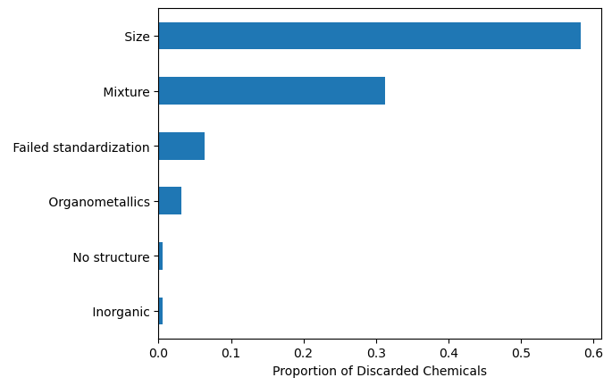

```python
ax = (
    new_discarded['Error']
    .value_counts(normalize=True)
    .sort_values(ascending=True)
    .plot(kind='barh')
)
ax.set_xlabel('Proportion of Discarded Chemicals')
```

## Compare QSAR-ready SMILES: Original versus new

```python
new_processed, original_processed = new_processed.align(original_processed, join='inner')

where_discrepancy = new_processed != original_processed

discrepancy_count = where_discrepancy.sum()
discrepancy_percent = discrepancy_count / len(new_processed) * 100

f'{round(discrepancy_count)} ({round(discrepancy_percent)}%) chemicals have discrepancy in QSAR_Ready_SMILES'
```

```
'105086 (22%) chemicals have discrepancy in QSAR_Ready_SMILES'
```

```python
idx = 0

original_smiles = original_processed[where_discrepancy].iloc[idx]
new_smiles = new_processed[where_discrepancy].iloc[idx]
```

```python
original_smiles
```

```
'CC1=CC(=CC=C1)C1N=C(CC(F)(F)F)SC=1C1=CC(N)=NC=C1'
```

```python
new_smiles
```

```
'CC1C=C(C=CC=1)C1N=C(CC(F)(F)F)SC=1C1=CC(N)=NC=C1'
```

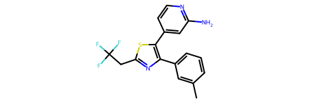

```python
original_mol = Chem.MolFromSmiles(original_smiles)
original_mol
```

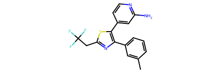

```python
new_mol = Chem.MolFromSmiles(new_smiles)
new_mol
```

```python
Chem.MolToInchiKey(original_mol) == Chem.MolToInchiKey(new_mol)
```

```
True
```

### Investigate discrepancies

I used the RDKit library to evaluate whether these discrepancies reflected different molecules or simply different ways of representing the same molecule. Specifically, I parsed the QSAR-ready SMILES into molecular objects (Mols), and then into InchiKey representations. I then evaluated whether these InchiKeys were identical for each chemical with a discrepancy in the QSAR-ready-SMILES.

```python
def main_analysis(original_smiles_series, new_smiles_series):
    """
    Main function to analyze discrepancies in QSAR-ready SMILES strings.

    Parameters:
    original_smiles_series (pd.Series): Series containing original SMILES strings.
    new_smiles_series (pd.Series): Series containing new SMILES strings.

    Returns:
    dict: Summary of the analysis including percents and error categorization.
    """
    # Filter out errors and analyze valid SMILES
    original_valid, original_errors = filter_smiles_errors(original_smiles_series)
    new_valid, new_errors = filter_smiles_errors(new_smiles_series)

    # Calculate percents
    original_error_percent = len(original_errors) / len(original_smiles_series) * 100
    new_error_percent = len(new_errors) / len(new_smiles_series) * 100

    matching_percent, non_matching_percent = evaluate_chemical_identity(original_valid, new_valid)

    # Compile results
    results = {
        "original_error_percent": original_error_percent,
        "new_error_percent": new_error_percent,
        "matching_valid_percent": matching_percent,
        "non_matching_valid_percent": non_matching_percent
    }

    return results

def filter_smiles_errors(smiles_list):
    """
    Filter out SMILES strings that cause errors when converted to molecules.

    Parameters:
    smiles_list (pd.Series): Series containing SMILES strings.

    Returns:
    tuple: A tuple containing two lists: valid SMILES and SMILES that caused errors.
    """
    valid_smiles = []
    error_smiles = []

    for smiles in smiles_list:
        mol = Chem.MolFromSmiles(smiles)
        if mol is None:
            error_smiles.append(smiles)
        else:
            valid_smiles.append(smiles)

    return valid_smiles, error_smiles

def analyze_smiles_errors(error_list):
    """
    Analyze SMILES strings that caused errors and categorize the errors.

    Parameters:
    error_list (list): List of tuples containing SMILES strings and their corresponding error messages.

    Returns:
    dict: Dictionary categorizing the types of errors encountered.
    """
    error_categories = {}

    for smiles, error_message in error_list:
        if error_message not in error_categories:
            error_categories[error_message] = []
        error_categories[error_message].append(smiles)

    return error_categories

def evaluate_chemical_identity(valid_original_smiles, valid_new_smiles):
    """
    Evaluate the identity of chemicals with valid SMILES strings and calculate the percents of matching and non-matching structures.

    Parameters:
    valid_original_smiles (list): List of valid original SMILES strings.
    valid_new_smiles (list): List of valid new SMILES strings.

    Returns:
    tuple: percent of matching structures, percent of non-matching structures.
    """
    matching_count = 0

    for original_smiles, new_smiles in zip(valid_original_smiles, valid_new_smiles):
        original_mol = Chem.MolFromSmiles(original_smiles)
        new_mol = Chem.MolFromSmiles(new_smiles)

        if Chem.MolToInchiKey(original_mol) == Chem.MolToInchiKey(new_mol):
            matching_count += 1

    total_count = len(valid_original_smiles)
    matching_percent = matching_count / total_count * 100
    non_matching_percent = 100 - matching_percent

    return matching_percent, non_matching_percent
```

```python
results = main_analysis(original_processed[where_discrepancy], new_processed[where_discrepancy])
```

[output not shown]

[output cut: 237 more lines]

[output not shown]

```python
pd.Series(results).round(2)
```

```
original_error_percent         0.26
new_error_percent              0.02
matching_valid_percent         0.74
non_matching_valid_percent    99.26
dtype: float64
```

## Conclusion

1. **Some QSAR-ready structures generated by OPERA appear invalid and fail to yield features:** We've designed a way to handle these chemicals by excluding them automatically in a recursive parallel for loop.
1. **OPERA may produce different QSAR-ready SMILES for the same chemical depending on how its run:** I think the new approach evaluated here offers greater flexibility in getting features for chemicals that are not in OPERA's internal database. However, the QSAR-ready SMILES may be different depending on the approach used. I'm unsure why this is the case.

Dr. Chiu - Simplest way to go forward, use internal database as the first tier. Some people have agreed on this. If not in the database, then run the workflow internally. Just be explicit in the methods. Recognize there may be some inconsistencies. Note whether pre-calculated or generated through the workflow.